# Wybory 2025

Tomasz Przechlewski

2025

## Dane

Pobrane ze strony PKW

Było 32143 komisji w pierwszej turze oraz 32143 komisji w drugiej turze. Oddano 20843805 głosów ważnych ogółem, w tym 10237177 na Rafała Trzaskowskiego oraz 10606628 na Karola Nawrockiego. PKW raportuje 20844163 ważnych głosów. Nie wnikałem z czego wynika różnica (oprócz tego że z trzech obwodów zagranicznych nie ma danych), ale nie ma praktycznego znaczenia.

## Pominięte komisje

Pomijamy komisje w których oddano 49 głosów w pierwszej albo drugiej turze. Pozostaje 30947 komisji. W pominętych komisjach oddano 15682 głosów na Rafała Trzaskowskiego oraz 19363 głosów na Karola Nawrockiego. Pominięte głosy na KN stanowią 0.0928957% wszystkich głosów ważnych (KN wygrał z RT przewagą około 1,77% głosów ważnych; pominięte głosy to zatem około 5.248345% tej przewagi.)

## Wykresy

Przyrosty względne tj. $(g_2 - g_1)/g_1 * 100%$. O ile procent wzrosła liczba głosów oddanych na kandydata w drugiej turze w porówaniu do pierwszej

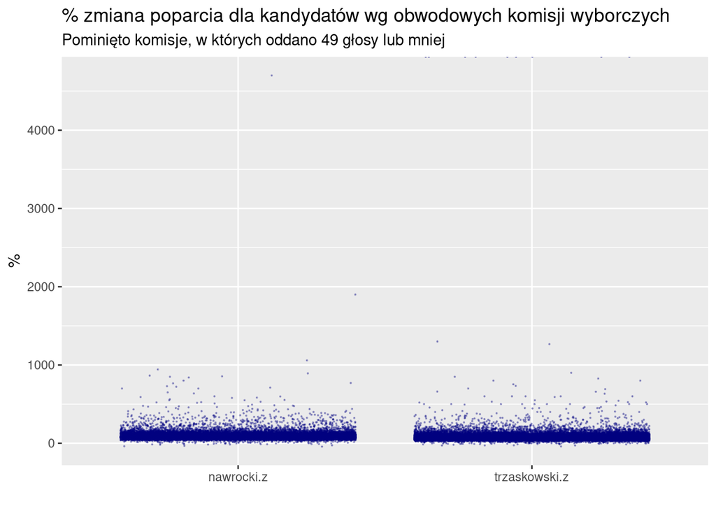

W 10 obwodach RT uzyskła w pierwszej turze 0 głosów (w tych komisjach RT uzyskał łącznie 97 głosów w drugiej turze, zaś KN uzyskał łącznie 1006 w pierwszej oraz 1533 w drugiej turze). W tych obwodach oczywiście wartość przyrostu względnego ma wartość *nieskończoność* ale dotyczy śladowej ilości głosów.

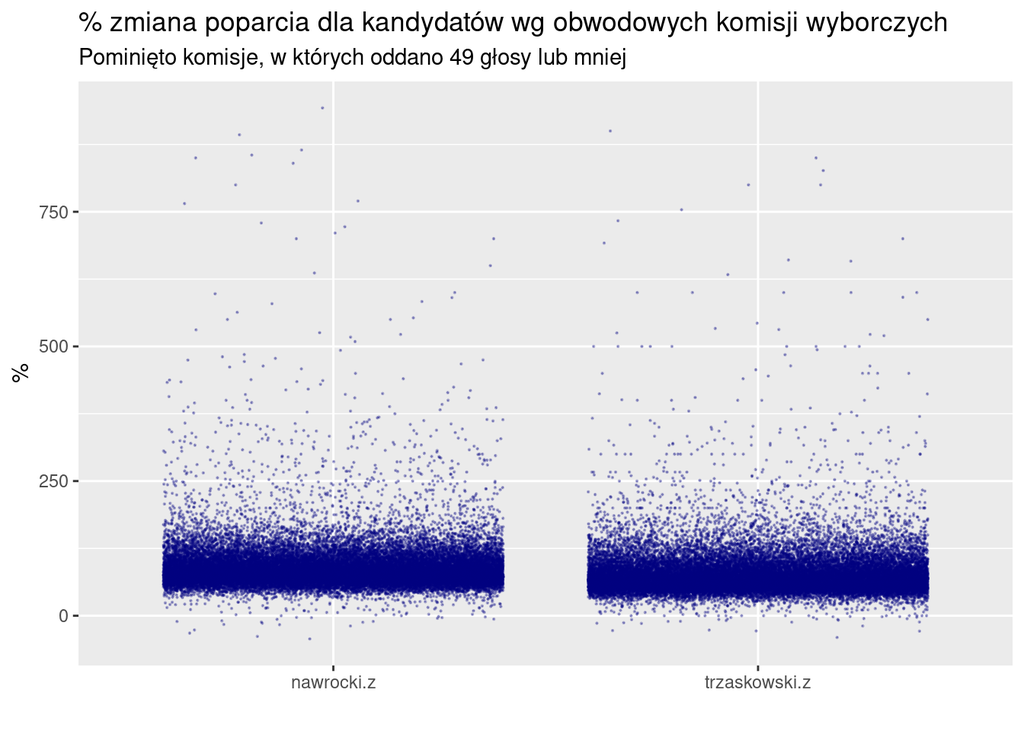

Z tego wykresu lepiej widać, że tylko w nielicznych obwodach odnotowano wynik mniejszy od zera i większy od 250%.

Na kolejnym wykresie zatem pominiemy także te komisje, których jest 611. KN zdobył w nich 164683 a RT 243577 głosów. Zajmiemy się tymi 611 komisjami później.

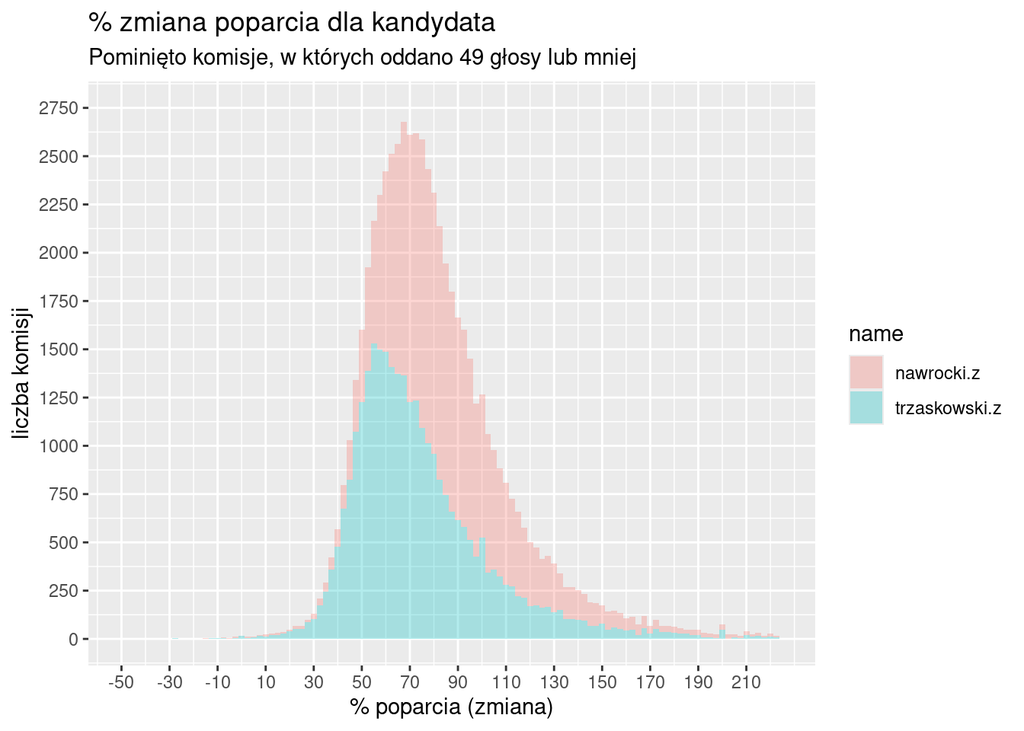

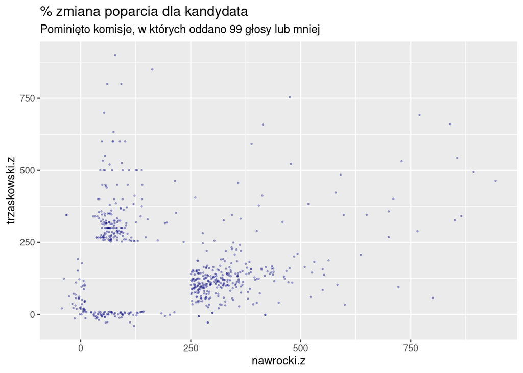